# Version Control

# Version Control

> A process of **tracking changes** to a file or set of files over time so that you can **recall specific versions later**.

## Git vs GitHub

- A system for version control that manages a collection of files in a structured way.
- Uses the command line or a GUI.
- Git is local.

## Git vs GitHub

- A system for version control that manages a collection of files in a structured way.
- Uses the command line or a GUI.
- Git is local.

[figure not shown]

- A cloud-based service that lets you use git across many computers.
- Basic services are free, advanced services are paid (like RStudio!).
- GitHub is remote.

## Why Learn GitHub?

1. GitHub provides a structured way for tracking changes to files over the course of a project.
- *Think Google Docs or Dropbox history, but more structured and powerful!*
2. GitHub makes it easy to have multiple people working on the same files at the same time.
3. You can host a URL of fun things (like the class text, these slides, the course website, etc.) with [GitHub pages](https://pages.github.com/).

## Git Repositories

Git is based on **repositories**.

- Think of a repository (**repo**) as a directory (folder) for a single project.
  - This directory will likely contain code, documentation, data, to do lists, etc. associated with the project.
  - You can link a local repo with a remote copy.

[figure not shown]

# Actions in Git

## Cloning a Repo

Create an exact copy of a remote repo on your local machine.

[figure not shown]

## Committing Changes

Tell git you have made changes you want to add to the repo.

- Also provide a *commit message* – a short label describing what the changes are and why they exist.

The red line is a change we commit (add) to the repo.

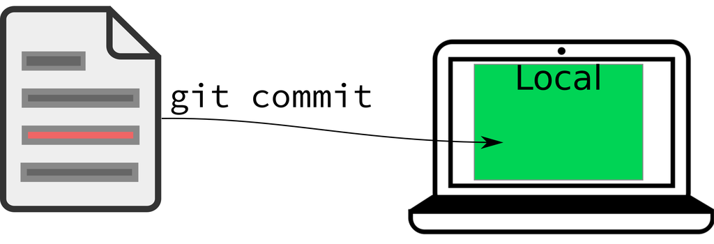

The log of these changes is called your *commit history*.

- You can always go back to old copies!

## Commit Tips

- Use short, but informative commit messages.
- Commit small blocks of changes – commit every time you accomplish a small task (e.g., one problem in the lab).
  - You’ll have a set of bite-sized changes (with description) to serve as a record of what you’ve done.
  - With frequent commits, its easier to find the issue if / when you mess up!

## Pushing Changes

Update the copy of your repo on GitHub so it has the most recent changes you’ve made on your machine.

[figure not shown]

## Pulling Changes

Update the local copy of your repo (the copy on your computer) with the version on GitHub.

[figure not shown]

## Workflow

**When you have an existing local repo:**

1. Pull the repo to make sure you have the most up to date version (especially if you are working on different computers).
2. Make some changes locally.
3. Commit the changes to git.
4. Push your changes to GitHub.

# Connect GitHub to RStudio

## Previous Steps

You were asked to complete the following steps **before** coming to class today:

1. Create a GitHub account
2. Introduce yourself to git (in RStudio)
3. Generate a Personal Access Token (PAT)
4. Store your PAT in RStudio

## Verifying Your Connection

Open RStudio and run the following code in your console (lower left pane):

```r
usethis::git_sitrep()
```

You should see something like:

```
── GitHub user
• Default GitHub host: 'https://github.com'
• Personal access token for 'https://github.com': '<discovered>'
• GitHub user: 'jcanner'
• Token scopes: 'admin:org, admin:public_key, delete:packages, delete_repo, gist, notifications, repo, user, workflow, write:packages'
• Email(s): 'jcanner@csumbedu'
12439090+jcanner@users.noreply.github.com'
ℹ No active usethis project
```

If that is not the case, Dr. Canner will help you troubleshoot in 5-minutes!